# Environmental Legislation and its Effects on Air Quality

## Introduction

The goal of this study is to examine the impact of certain variables on the climate by examining the AQI of counties across the United States of America using data collected by the EPA.

There are two smaller sub studies in this presentation: One examining the effects of the Climate Alliance legislative program, and another examining the correlation between aspects of counties and the air quality.

## Reading the Data and EDA

To begin we read the data in from the EPA datasets.

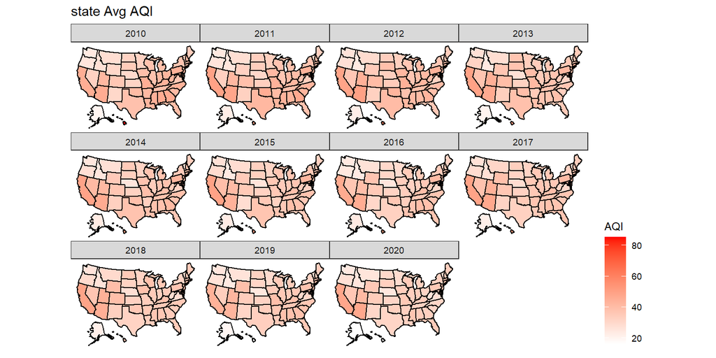

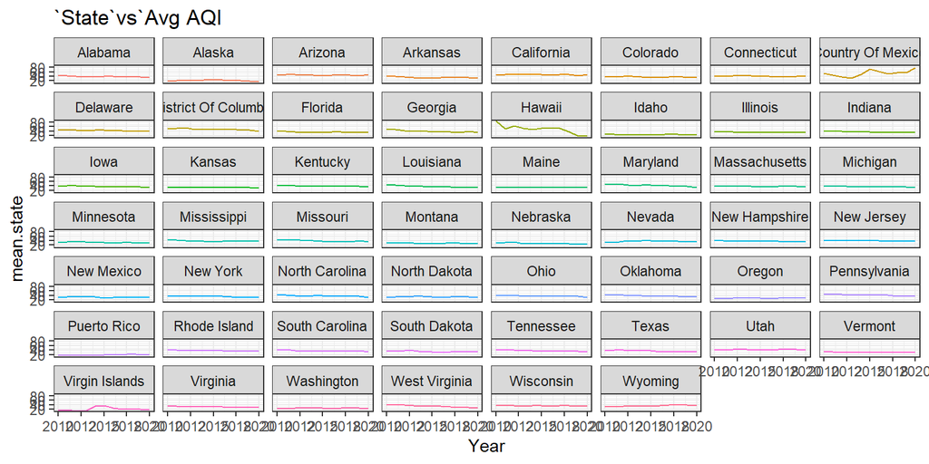

```
## 'data.frame':    41 obs. of  5 variables:
##  $ Year                 : int  1980 1981 1982 1983 1984 1985 1986 1987 1988 1989 ...
##  $ Mean                 : num  112.9 109.9 110.1 99.5 93.1 ...
##  $ Number.of.Trend.Sites: int  20 20 20 20 20 20 20 20 20 20 ...
##  $ X10th.Percentile     : num  66.5 66.5 66.5 59.5 59.8 ...
##  $ X90th.Percentile     : num  190 190 190 165 145 ...
```

```
##       Year           Mean       Number.of.Trend.Sites X10th.Percentile
##  Min.   :1980   Min.   : 40.5   Min.   :20            Min.   :29.4
##  1st Qu.:1990   1st Qu.: 48.3   1st Qu.:20            1st Qu.:37.0
##  Median :2000   Median : 66.6   Median :20            Median :45.0
##  Mean   :2000   Mean   : 71.3   Mean   :20            Mean   :46.5
##  3rd Qu.:2010   3rd Qu.: 94.4   3rd Qu.:20            3rd Qu.:56.0
##  Max.   :2020   Max.   :112.9   Max.   :20            Max.   :66.5
##  X90th.Percentile
##  Min.   : 55
##  1st Qu.: 65
##  Median :112
##  Mean   :116
##  3rd Qu.:165
##  Max.   :190
```

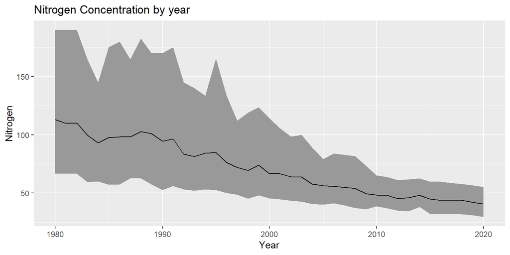

```
## 'data.frame':    31 obs. of  5 variables:
##  $ Year                 : int  1990 1991 1992 1993 1994 1995 1996 1997 1998 1999 ...
##  $ Mean                 : num  0.0877 0.0882 0.0837 0.0848 0.0851 ...
##  $ Number.of.Trend.Sites: int  394 394 394 394 394 394 394 394 394 394 ...
##  $ X10th.Percentile     : num  0.068 0.067 0.068 0.065 0.069 0.071 0.07 0.068 0.071 0.07 ...
##  $ X90th.Percentile     : num  0.108 0.11 0.098 0.103 0.099 0.109 0.1 0.102 0.107 0.104 ...
```

```
##       Year           Mean        Number.of.Trend.Sites X10th.Percentile
##  Min.   :1990   Min.   :0.0652   Min.   :394           Min.   :0.0540
##  1st Qu.:1998   1st Qu.:0.0694   1st Qu.:394           1st Qu.:0.0600
##  Median :2005   Median :0.0787   Median :394           Median :0.0650
##  Mean   :2005   Mean   :0.0780   Mean   :394           Mean   :0.0645
##  3rd Qu.:2012   3rd Qu.:0.0849   3rd Qu.:394           3rd Qu.:0.0680
##  Max.   :2020   Max.   :0.0896   Max.   :394           Max.   :0.0710
##  X90th.Percentile
##  Min.   :0.075
##  1st Qu.:0.080
##  Median :0.092
##  Mean   :0.092
##  3rd Qu.:0.101
##  Max.   :0.110
```

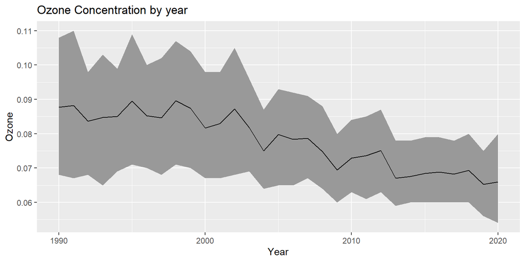

```
## 'data.frame':    41 obs. of  5 variables:
##  $ Year                 : int  1980 1981 1982 1983 1984 1985 1986 1987 1988 1989 ...
##  $ Mean                 : num  162 154 141 154 142 ...
##  $ Number.of.Trend.Sites: int  32 32 32 32 32 32 32 32 32 32 ...
##  $ X10th.Percentile     : num  50 50 40 37 30 40 30 25 30 30 ...
##  $ X90th.Percentile     : num  271 251 250 321 280 250 258 242 220 261 ...
```

```
##       Year           Mean       Number.of.Trend.Sites X10th.Percentile
##  Min.   :1980   Min.   : 10.3   Min.   :32            Min.   : 3.0
##  1st Qu.:1990   1st Qu.: 40.9   1st Qu.:32            1st Qu.:10.9
##  Median :2000   Median : 82.0   Median :32            Median :26.0
##  Mean   :2000   Mean   : 82.0   Mean   :32            Mean   :23.2
##  3rd Qu.:2010   3rd Qu.:118.4   3rd Qu.:32            3rd Qu.:31.0
##  Max.   :2020   Max.   :162.4   Max.   :32            Max.   :50.0
##  X90th.Percentile
##  Min.   : 16
##  1st Qu.: 84
##  Median :151
##  Mean   :150
##  3rd Qu.:218
##  Max.   :321
```

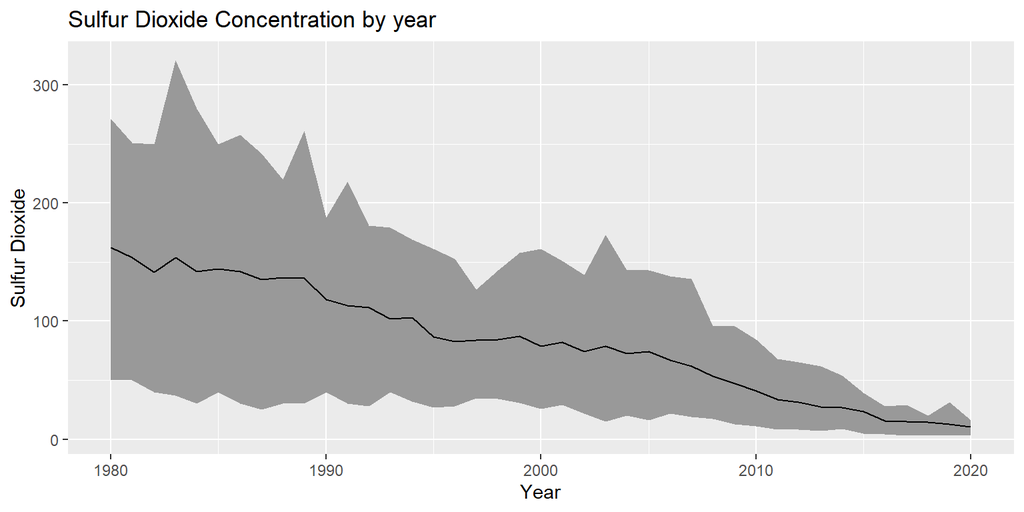

```
## 'data.frame':    11 obs. of  5 variables:
##  $ Year                 : int  2010 2011 2012 2013 2014 2015 2016 2017 2018 2019 ...
##  $ Mean                 : num  0.2272 0.2277 0.2013 0.1378 0.0776 ...
##  $ Number.of.Trend.Sites: int  83 83 83 83 83 83 83 83 83 83 ...
##  $ X10th.Percentile     : num  0.01 0.01 0.01 0.01 0.01 0.01 0.01 0.01 0 0 ...
##  $ X90th.Percentile     : num  0.64 0.66 0.51 0.43 0.17 0.11 0.12 0.11 0.11 0.09 ...
```

```
##       Year           Mean        Number.of.Trend.Sites X10th.Percentile
##  Min.   :2010   Min.   :0.0320   Min.   :83            Min.   :0.00000
##  1st Qu.:2012   1st Qu.:0.0437   1st Qu.:83            1st Qu.:0.00500
##  Median :2015   Median :0.0478   Median :83            Median :0.01000
##  Mean   :2015   Mean   :0.1017   Mean   :83            Mean   :0.00727
##  3rd Qu.:2018   3rd Qu.:0.1696   3rd Qu.:83            3rd Qu.:0.01000
##  Max.   :2020   Max.   :0.2277   Max.   :83            Max.   :0.01000
##  X90th.Percentile
##  Min.   :0.060
##  1st Qu.:0.110
##  Median :0.120
##  Mean   :0.274
##  3rd Qu.:0.470
##  Max.   :0.660
```

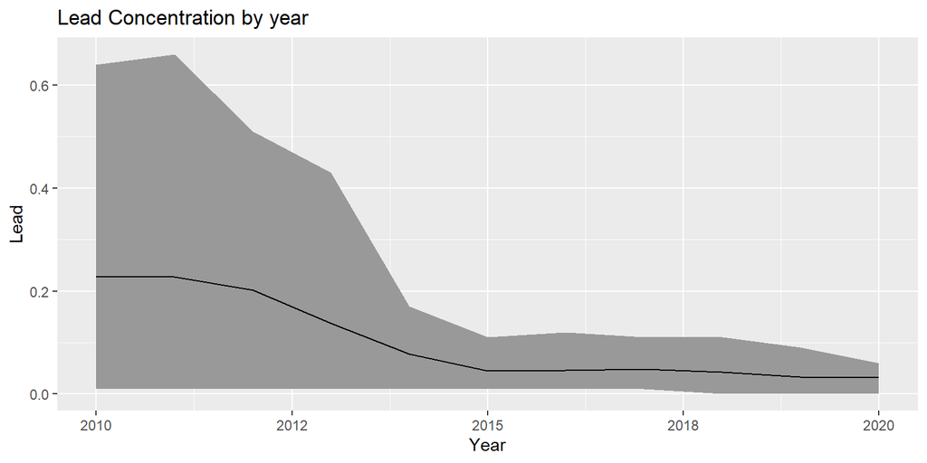

```
## 'data.frame':    41 obs. of  5 variables:
##  $ Year                 : int  1980 1981 1982 1983 1984 1985 1986 1987 1988 1989 ...
##  $ Mean                 : num  9.46 9.21 8.59 9.11 8.34 ...
##  $ Number.of.Trend.Sites: int  36 36 36 36 36 36 36 36 36 36 ...
##  $ X10th.Percentile     : num  4.6 3.9 4.8 4.5 4.4 3.9 4.5 4.5 4.1 3.6 ...
##  $ X90th.Percentile     : num  16.8 14.6 13.9 16.2 13.7 12.3 12.6 10.2 10.5 10.4 ...
```

```
##       Year           Mean      Number.of.Trend.Sites X10th.Percentile
##  Min.   :1980   Min.   :1.27   Min.   :36            Min.   :0.70
##  1st Qu.:1990   1st Qu.:1.76   1st Qu.:36            1st Qu.:0.90
##  Median :2000   Median :3.79   Median :36            Median :2.00
##  Mean   :2000   Mean   :4.31   Mean   :36            Mean   :2.33
##  3rd Qu.:2010   3rd Qu.:6.56   3rd Qu.:36            3rd Qu.:3.60
##  Max.   :2020   Max.   :9.46   Max.   :36            Max.   :4.80
##  X90th.Percentile
##  Min.   : 1.80
##  1st Qu.: 2.60
##  Median : 5.40
##  Mean   : 6.61
##  3rd Qu.: 9.80
##  Max.   :16.80
```

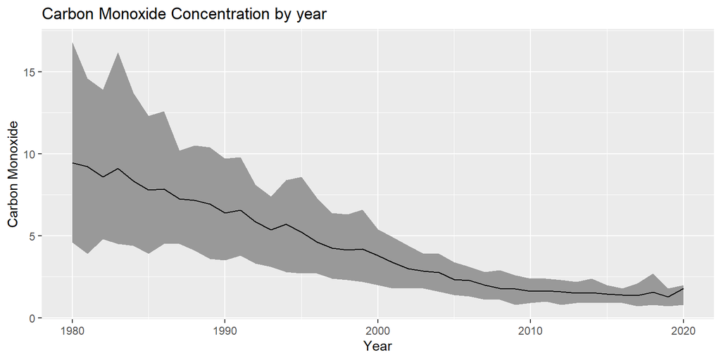

```
## 'data.frame':    31 obs. of  5 variables:
##  $ Year                 : int  1990 1991 1992 1993 1994 1995 1996 1997 1998 1999 ...
##  $ Mean                 : num  86.2 85.4 73.5 74 72.1 ...
##  $ Number.of.Trend.Sites: int  100 100 100 100 100 100 100 100 100 100 ...
##  $ X10th.Percentile     : num  45 46 39 41 34 37 34 36.5 37 39 ...
##  $ X90th.Percentile     : num  145 134 112 124 124 ...
```

```
##       Year           Mean      Number.of.Trend.Sites X10th.Percentile
##  Min.   :1990   Min.   :46.0   Min.   :100           Min.   :24.5
##  1st Qu.:1998   1st Qu.:56.1   1st Qu.:100           1st Qu.:27.5
##  Median :2005   Median :62.5   Median :100           Median :33.0
##  Mean   :2005   Mean   :62.3   Mean   :100           Mean   :32.6
##  3rd Qu.:2012   3rd Qu.:65.7   3rd Qu.:100           3rd Qu.:37.0
##  Max.   :2020   Max.   :86.2   Max.   :100           Max.   :46.0
##  X90th.Percentile
##  Min.   : 73.0
##  1st Qu.: 90.5
##  Median : 96.5
##  Mean   :102.7
##  3rd Qu.:113.2
##  Max.   :145.0
```

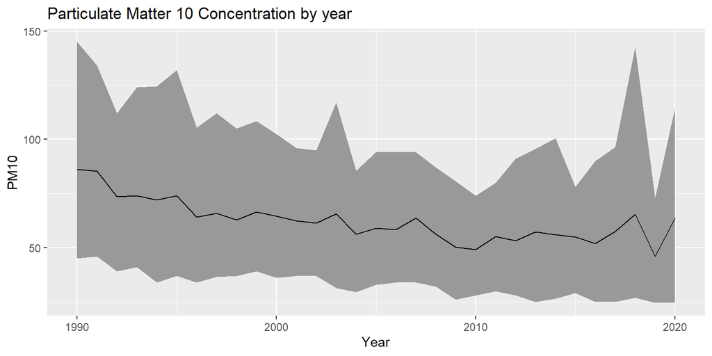

```
## 'data.frame':    21 obs. of  5 variables:
##  $ Year                 : int  2000 2001 2002 2003 2004 2005 2006 2007 2008 2009 ...
##  $ Mean                 : num  13.5 13.2 12.8 12.3 12 ...
##  $ Number.of.Trend.Sites: int  390 390 390 390 390 390 390 390 390 390 ...
##  $ X10th.Percentile     : num  8.73 8.65 8.61 7.9 7.65 ...
##  $ X90th.Percentile     : num  18 17.3 16.6 16.2 15.7 ...
```

```
##       Year           Mean       Number.of.Trend.Sites X10th.Percentile
##  Min.   :2000   Min.   : 7.63   Min.   :390           Min.   :5.62
##  1st Qu.:2005   1st Qu.: 8.54   1st Qu.:390           1st Qu.:6.10
##  Median :2010   Median : 9.88   Median :390           Median :6.68
##  Mean   :2010   Mean   :10.29   Mean   :390           Mean   :6.97
##  3rd Qu.:2015   3rd Qu.:12.02   3rd Qu.:390           3rd Qu.:7.71
##  Max.   :2020   Max.   :13.50   Max.   :390           Max.   :8.73
##  X90th.Percentile
##  Min.   : 9.51
##  1st Qu.:10.75
##  Median :12.41
##  Mean   :13.25
##  3rd Qu.:15.67
##  Max.   :18.04
```

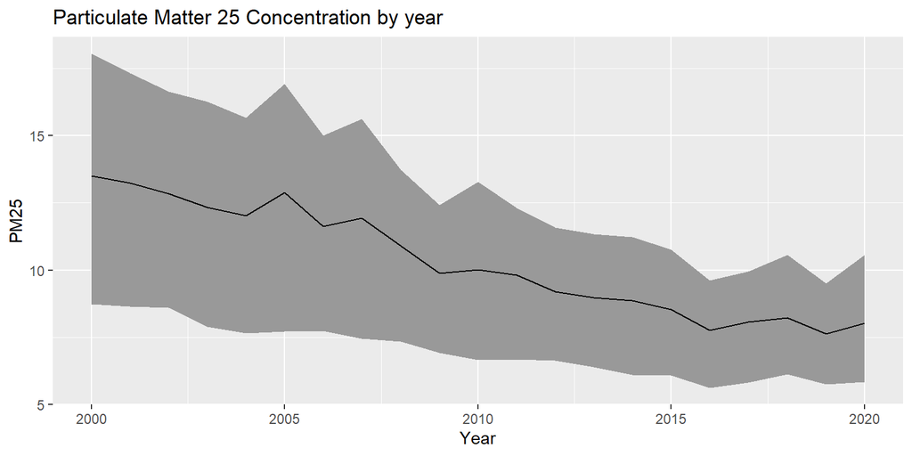

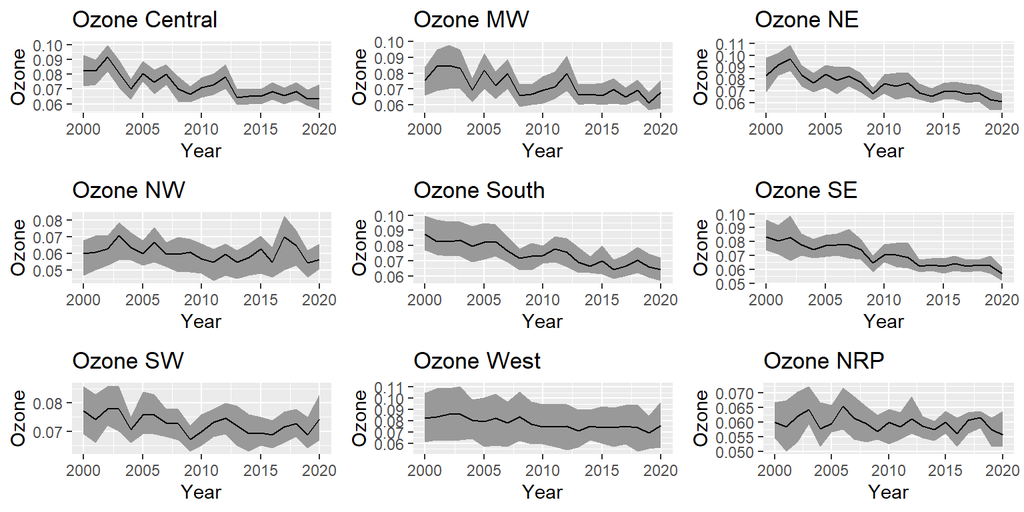

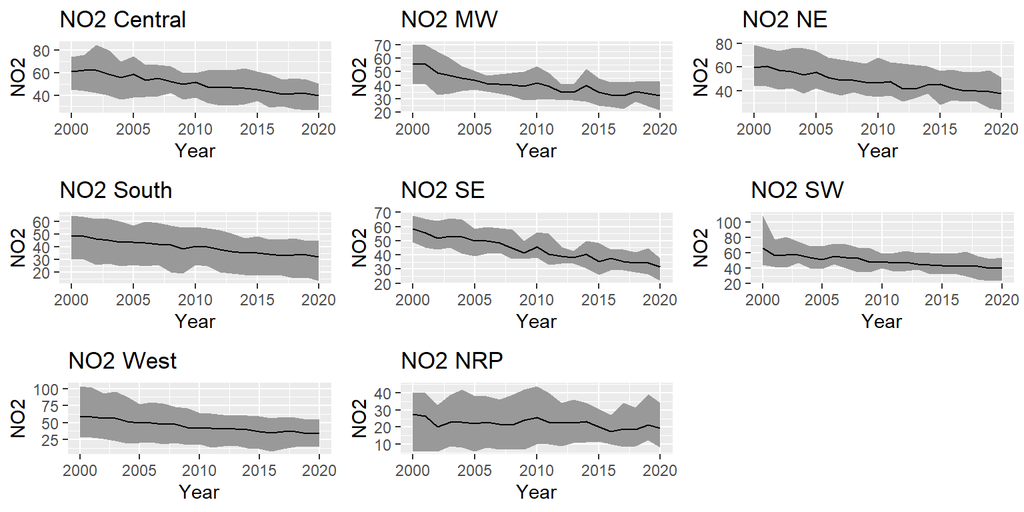

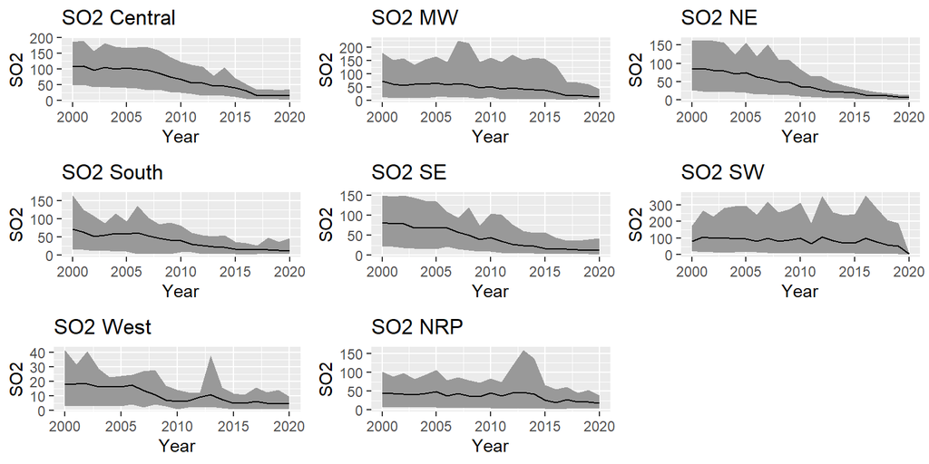

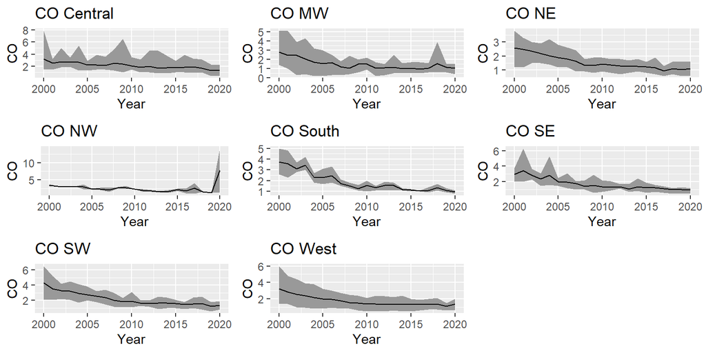

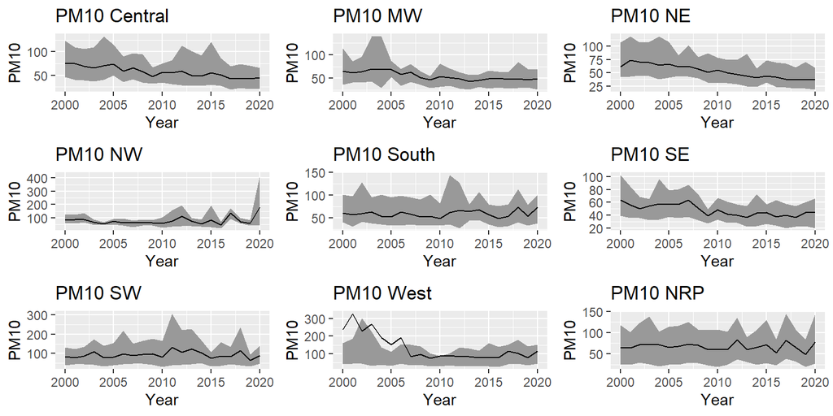

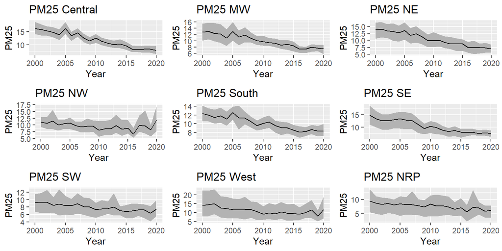

## Climate Alliance

```
##
## Call:
## lm(formula = med.aqi ~ is.climate.alli + state, data = focus_data)
##
## Residuals:
##    Min     1Q Median     3Q    Max
## -36.82  -3.06   1.36   5.68  94.52
##
## Coefficients: (1 not defined because of singularities)
##                           Estimate Std. Error t value Pr(>|t|)
## (Intercept)                37.5294     1.8246   20.57  < 2e-16 ***
## is.climate.alliyes         -1.1008     2.3131   -0.48  0.63418
## stateAlaska               -17.0000     3.1602   -5.38  8.3e-08 ***
## stateArizona                6.3167     2.7717    2.28  0.02277 *
## stateArkansas              -1.7294     2.8029   -0.62  0.53730
## stateCalifornia             9.8827     1.7575    5.62  2.1e-08 ***
## stateColorado               0.3419     1.9689    0.17  0.86215
## stateConnecticut            2.1339     3.0158    0.71  0.47929
## stateCountry Of Mexico     18.9706     5.6237    3.37  0.00076 ***
## stateDelaware               4.7381     4.5701    1.04  0.29997
## stateDistrict Of Columbia   6.4706     7.7409    0.84  0.40331
## stateFlorida               -2.3371     2.1864   -1.07  0.28522
## stateGeorgia               -0.8570     2.2979   -0.37  0.70923
## stateHawaii                -8.4286     4.0211   -2.10  0.03620 *
## stateIdaho                -12.5294     2.4544   -5.10  3.6e-07 ***
## stateIllinois              -1.1323     2.0291   -0.56  0.57689
## stateIndiana               -3.4669     2.1780   -1.59  0.11159
## stateIowa                  -1.2169     2.6203   -0.46  0.64240
## stateKansas                -5.2112     2.9110   -1.79  0.07357 .
## stateKentucky               0.5261     2.3292    0.23  0.82131
## stateLouisiana             -2.4068     2.1170   -1.14  0.25571
## stateMaine                 -2.0786     2.7714   -0.75  0.45333
## stateMaryland               1.3950     2.3131    0.60  0.54652
## stateMassachusetts         -0.2986     2.7717   -0.11  0.91421
## stateMichigan              -1.5536     2.0106   -0.77  0.43979
## stateMinnesota             -5.7857     2.1717   -2.66  0.00778 **
## stateMississippi           -0.0056     2.9528    0.00  0.99849
## stateMissouri              -1.0502     2.3847   -0.44  0.65969
## stateMontana               -9.6610     2.5115   -3.85  0.00012 ***
## stateNebraska             -11.4739     3.1012   -3.70  0.00022 ***
```

[output cut: 16 more lines]

```
## stateTexas                 -4.8593     2.1204   -2.29  0.02202 *
## stateUtah                   5.7039     2.6649    2.14  0.03244 *
## stateVermont               -7.0536     4.0211   -1.75  0.07956 .
## stateVirgin Islands       -14.8628     4.7110   -3.15  0.00163 **
## stateVirginia              -6.9139     1.9198   -3.60  0.00032 ***
## stateWashington           -10.7892     1.9689   -5.48  4.8e-08 ***
## stateWest Virginia         -8.3732     2.6203   -3.20  0.00142 **
## stateWisconsin                  NA         NA      NA       NA
## stateWyoming                1.6650     2.5442    0.65  0.51290
## ---
## Signif. codes:  0 '***' 0.001 '**' 0.01 '*' 0.05 '.' 0.1 ' ' 1
##
## Residual standard error: 10.6 on 2055 degrees of freedom
## Multiple R-squared:  0.187,  Adjusted R-squared:  0.166
## F-statistic: 8.92 on 53 and 2055 DF,  p-value: <2e-16
```

Climate Alliance states tend to have a better AQI on average but it is not significant.

This might be because the Climate Alliance only went into effect 3 years ago in 2017.

## County Level Effects on AQI

Using the data found by the USDA’s Economic Research Service, we look for predictors in counties to determine air quality and find correlations. This begins by merging the 2019 AQI with the latest USDA ERS data. We use 2019 data to avoid skewing due to the 2020 West Coast fires.

To begin the analysis, we start by merging county data with AQI data. We start by merging all three sets of ERS county data, and then we merge by county and state.

We only take the data from year 2019 to keep it consistent. We are avoiding using 2020 data due to the fires on the West coast skewing data.

Break the cleaned and merged dataset into X and Y for use with cv.glmnet. We use set.seed(1) for consistency.

```
## Note: Using an external vector in selections is ambiguous.
## i Use `all_of(select_cols)` instead of `select_cols` to silence this message.
## i See <https://tidyselect.r-lib.org/reference/faq-external-vector.html>.
```

```
## Anova Table (Type II tests)
##
## Response: med.aqi
##                      Sum Sq  Df F value  Pr(>F)
## state                 15670  48    3.44 2.5e-13 ***
## PctEmpAgriculture       109   1    1.15  0.2848
## PctEmpConstruction      174   1    1.83  0.1761
## PctEmpFIRE              734   1    7.73  0.0055 **
## Age65AndOlderPct2010     50   1    0.53  0.4676
## Ed4AssocDegreePct       774   1    8.16  0.0044 **
## FemaleHHPct            1681   1   17.71 2.8e-05 ***
## HH65PlusAlonePct        578   1    6.09  0.0138 *
## Ed3SomeCollegeNum       737   1    7.77  0.0054 **
## ForeignBornMexNum       610   1    6.43  0.0114 *
## NetMigrationNum0010    1698   1   17.90 2.6e-05 ***
## Residuals             89962 948
## ---
## Signif. codes:  0 '***' 0.001 '**' 0.01 '*' 0.05 '.' 0.1 ' ' 1
```

From the Anova call above, we see that Age65AndOlderPct2010 is the least relevant, so we remove it.

```
## Anova Table (Type II tests)
##
## Response: med.aqi
##                     Sum Sq  Df F value  Pr(>F)
## state                15623  48    3.43 2.9e-13 ***
## PctEmpAgriculture       92   1    0.97  0.3246
## PctEmpConstruction     143   1    1.50  0.2205
## PctEmpFIRE             723   1    7.62  0.0059 **
## Ed4AssocDegreePct      744   1    7.84  0.0052 **
## FemaleHHPct           1652   1   17.41 3.3e-05 ***
## HH65PlusAlonePct       950   1   10.01  0.0016 **
## Ed3SomeCollegeNum      732   1    7.72  0.0056 **
## ForeignBornMexNum      618   1    6.52  0.0108 *
## NetMigrationNum0010   1683   1   17.74 2.8e-05 ***
## Residuals            90012 949
## ---
## Signif. codes:  0 '***' 0.001 '**' 0.01 '*' 0.05 '.' 0.1 ' ' 1
```

From the Anova call above, we see that PctEmpAgriculture is the least relevant, so we remove it.

```
## Anova Table (Type II tests)
##
## Response: med.aqi
##                     Sum Sq  Df F value  Pr(>F)
## state                16002  48    3.51 8.3e-14 ***
## PctEmpConstruction     124   1    1.31 0.25270
## PctEmpFIRE            1037   1   10.93 0.00098 ***
## Ed4AssocDegreePct      685   1    7.22 0.00732 **
## FemaleHHPct           1667   1   17.58 3.0e-05 ***
## HH65PlusAlonePct      1046   1   11.03 0.00093 ***
## Ed3SomeCollegeNum      786   1    8.29 0.00408 **
## ForeignBornMexNum      614   1    6.47 0.01112 *
## NetMigrationNum0010   1704   1   17.96 2.5e-05 ***
## Residuals            90104 950
## ---
## Signif. codes:  0 '***' 0.001 '**' 0.01 '*' 0.05 '.' 0.1 ' ' 1
```

From the Anova call above, we see that PctEmpConstruction is the least relevant, so we remove it.

```
## Anova Table (Type II tests)
##
## Response: med.aqi
##                     Sum Sq  Df F value  Pr(>F)
## state                16606  48    3.65 1.1e-14 ***
## PctEmpFIRE            1127   1   11.88 0.00059 ***
## Ed4AssocDegreePct      733   1    7.73 0.00555 **
## FemaleHHPct           1974   1   20.81 5.7e-06 ***
## HH65PlusAlonePct      1139   1   12.01 0.00055 ***
## Ed3SomeCollegeNum      814   1    8.58 0.00348 **
## ForeignBornMexNum      582   1    6.13 0.01347 *
## NetMigrationNum0010   1679   1   17.69 2.8e-05 ***
## Residuals            90228 951
## ---
## Signif. codes:  0 '***' 0.001 '**' 0.01 '*' 0.05 '.' 0.1 ' ' 1
```

```
##                      Estimate Std. Error t value Pr(>|t|)
## PctEmpFIRE           6.13e-01   1.78e-01    3.45 5.91e-04
## Ed4AssocDegreePct   -5.29e-01   1.90e-01   -2.78 5.55e-03
## FemaleHHPct          5.35e-01   1.17e-01    4.56 5.73e-06
## HH65PlusAlonePct    -4.73e-01   1.36e-01   -3.47 5.53e-04
## Ed3SomeCollegeNum    1.42e-05   4.86e-06    2.93 3.48e-03
## ForeignBornMexNum    2.15e-05   8.67e-06    2.48 1.35e-02
## NetMigrationNum0010  2.78e-05   6.61e-06    4.21 2.84e-05
```

From the final model, we see that most of the impact on AQI is geographical. For example, the increase from ForeignBornMexNum and NetMigrationNum could signal that states closer to the Mexican border tend to have worse AQIs due to their location. However, the most clear predictors are the states themselves.

The assumptions for linearity appear to hold up until about 1 standard deviation below the mean.

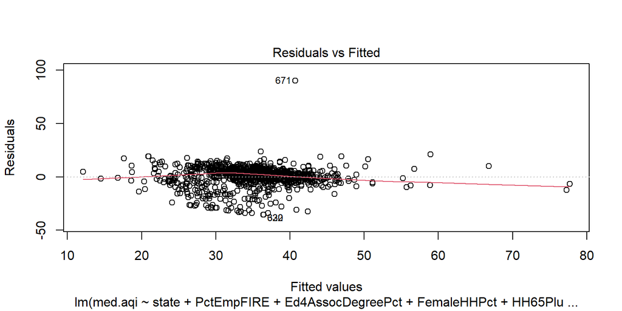

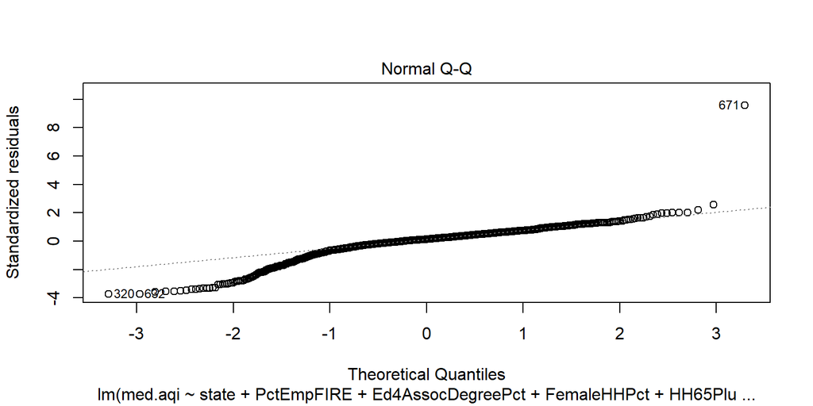

## Conclusion

The overall objective of this study was to use the AQI of counties across the USA to determine the impact of variables on the climate. Using data collected by the EPA, we were able to focus on the effect of the Climate Alliance on curbing the deterioration of the AQI across the nation, as well as the correlation between aspects of counties and their air quality.

From this study, we were able to conclude that the Climate Alliance has not had much of an effect yet on the AQI of member states, but do have better AQIs on average compared to other states. We were also able to see that most of the impact on the AQI is geographical based on the significant variables of the model.